# Analyzing Dominant Modes of User Behaviors Through Deterministic Model

by Jason G. Lomnitz<sup>1</sup>

February 9<sup>th</sup>, 2016  
<sup>1</sup>Post-Doctoral Scholar, Department of Biomedical Engineering, University of California, Davis, CA 95616  
email:jason.lomnitz@gmail.com; phone:(530) 902 0421

© 2016 Jason Lomnitz. All rights reserved.

Online services process large numbers of transactions from a variety of events that originate from user activity. The data from these transactions can be leveraged to provide valuable information surrounding multiple aspects of user interactions with a given product. The challenge is to analyze these data to identify patterns of user behavior to gain an understanding of critical bottlenecks that can be targeted for an overall improvement in user experience and product quality. Thus, analysis of data is poised to provide critical feedback to inform the decision-making process.

A strategy that can provide valuable information regarding patterns in user behavior is to create mathematical models that capture the important processes within a particular system. Here, I present an analysis of a mathematical model that I have proposed that is motivated by the blog posted by Danny Hernandez<sup>[1](http://blog.twitch.tv/2015/05/science-surfing-the-4th-largest-stream-of-data/)</sup> of the Twitch Science Team. My goal with this exercise is to illustrate (1) my communication skills, (2) my programming expertise, (3) my mathematical background and (4) my experience with analyzing mathematical models of complex systems. Through this exercise I use a software package that I have solely developed, the Design Space Toolbox V2, within a python-based scientific programming environment in the IPython notebook. This exercise should illustrate a very different modeling approach that is unique because it analyzes a system based on dominant modes of operation through a combination of symbolic and numerical methods.

Readers not immediately interested in the fine details of the methods are directed to the **Results** section. Otherwise, readers can select the option to `Show Code` on the left-hand side of the page and proceed to the **Methods** section below. By selecting the `Show Code` option, the exported notebook will display the input blocks of the notebook with the python code for the corresponding output blocks.

## Methods

The analysis I present here uses a new approach to analyze mathematical models composed of non-linear ordinary differential equations (ODEs). This approach, known as the system design space methodology, deconstructs a complex system into a finite number of non-linear sub-systems that represent dominant modes of operation for a particular system. The sub-system equations have a regular structure that are analytically tractable for a variety of system properties. The sub-systems are defined mathematically from the system equations and their behavior is representative of the full system within mathematically defined boundaries. The boundaries define a feasible region that is a convex polytope within parameter plus independent variable space.

The Design Space Toolbox V2, which I have developed as a major component of my PhD work, automates the difficult steps of the system design space method. It combines a computer algebra system and a variety of numerical methods to provide a rich framework for model analysis and visualization. This software is composed of a hierarchy of components: a C library performs the bulk of the analysis using multi-threaded parallel approaches; a SWIG-generated C-Python interface exposes the low-level functionality of the C library to Python; a Python Package provides a higher level interface that is object-oriented within a scientific programming environment; and a IPython-based widget provides a basic graphical user interface for wider accesibility.

Before I proceed with the description of the methodology, I import the packages that will be used throughout this IPython notebook,

```python
import IPython
from IPython.display import HTML, display
from integrate import integrate

import cStringIO
import base64

import random

def figure_data_stream(fig):
    canvas = FigureCanvasAgg(fig)
    buf = cStringIO.StringIO()
    canvas.print_png(buf)
    data = buf.getvalue()
    return base64.b64encode(data)
```

For reproducibility, the analysis shown here has been performed with the following packages and versions,

```python
import dspace
import dspace.plotutils
import dspace.display

import matplotlib as mt
import matplotlib.pyplot as plt
from matplotlib.backends.backend_agg import FigureCanvasAgg

import numpy as np

import notebook

package_data = {'Design Space Toolbox V2':dspace,
                'Matplotlib': mt,
                'NumPy': np,
                'Notebook':notebook,
                'IPython':IPython}

HTML('<br>'.join(['<b>{0}:</b> {1}'.format(key,
                                           value.__version__)
                  for key,value in package_data.iteritems()]))
```

**Design Space Toolbox V2:** 0.3.0a4  
**IPython:** 4.0.0  
**Notebook:** 4.0.4  
**NumPy:** 1.8.0rc1  
**Matplotlib:** 1.3.1

### Mathematical Models of Complex Phenomena

The analysis of complex systems does not begin with mathematical models; instead, they typically begin with a conceptual model that captures the key aspecs of a particular system. These features typically include interactions between different components and transiitons between different states. The conceptual model for the system I will analyze is shown in Figure 1. This conceptual model represents users interacting with the Twitch platform, grouped according to their activities – i.e. starting a new session, viewing an online channel, browsing channels, viewing a live channel, successfully watching a video for more than 5 mins. These groups represent different states, and users can transition between states at particular rates that may vary as a function of a variety of independent variables that include the number of available channels, events such as tournaments, time of day, etc.

Mathematical and computational models can be formulated on the basis of these conceptual models that capture different aspects of the system behavior. For example, probabilistic models using Monte Carlo approaches model individual behaviors according to a particular set of rules. Alternatively, determininstic models can be formulated using differential equations that focus on the behavior of the system at the population-level, by modeling the average rates at which the transition between the states occur. These models can be useful to identify basic principles of a qualitative nature (i.e. principles that are independent of fine quantitative detail), through both numerical as well as analytical results.

In this analysis, I formulate a simple deterministic model defined by a system of differential equations that captures the change of each state variable as defined in the conceptual model. The right-hand side of each equation has a set of positive and negative rate-laws, where the rate-laws correspond to a specific mechanism or an aggregation of mechanisms by which users transition from one state to another, and corresponds to one of the arrows in the conceptual model. Each of these rate equations can be represented mathematically using a power-laws – the advantage of being that they can capture non-linear behavior over wide-ranges and are self-similar and thus independent of scale.

### Mathematical Model of User Sessions at a Population Level

The detailed mathematical model I will analyze in this notebook is defined by the following system of differential equations.

$\frac{dO}{dt} = \overbrace{\alpha_1 n \omega^{-1}}^{n \rightarrow O} + \overbrace{k_{31} \upsilon \omega^{-\frac{1}{2}}}^{\upsilon \rightarrow O} - \overbrace{k_{12} O}^{O \rightarrow b} - \overbrace{k_{13} O \omega^{\frac{1}{2}}}^{O \rightarrow \upsilon} - \overbrace{\beta_1 O}^{O \rightarrow \emptyset}$

$\frac{db}{dt} = \overbrace{k_{12} O}^{O \rightarrow b} + \overbrace{k_{32} \upsilon}^{\upsilon \rightarrow b} - \overbrace{k_{23} b}^{b \rightarrow \upsilon} - \overbrace{\beta_2 b}^{b \rightarrow \emptyset}$

$\frac{d\upsilon}{dt} = \overbrace{k_{23} b}^{b \rightarrow \upsilon} + \overbrace{\alpha_2 n \omega}^{n \rightarrow \upsilon} + \overbrace{k_{13} O \omega^{\frac{1}{2}}}^{O \rightarrow \upsilon} - \overbrace{k_{34} \upsilon}^{\upsilon \rightarrow S} - \overbrace{\beta_3 \upsilon}^{\upsilon \rightarrow \emptyset} - \overbrace{k_{32} \upsilon}^{\upsilon \rightarrow b} - \overbrace{k_{31} \upsilon \omega^{-\frac{1}{2}}}^{\upsilon \rightarrow O}$

$\frac{dS}{dt} = \overbrace{k_{34} \upsilon}^{\upsilon \rightarrow S} - \overbrace{k_{45} S}^{S \rightarrow n} - \overbrace{\beta_4 S}^{S \rightarrow \emptyset}$

$\frac{dn}{dt} = \overbrace{\alpha_n}^{\rightarrow n} + \overbrace{k_{45} S}^{S \rightarrow n} - \overbrace{\alpha_1 n \omega^{-1}}^{n \rightarrow O} - \overbrace{\alpha_2 n \omega}^{n \rightarrow \upsilon}$

where $O$ represents the number of people currently on an offline channel; $b$ represents the number of people browsing channels; $\upsilon$ represents the number of people actively viewing a video; $S$ represents the number of people that have 'succeded' by watching a video for 5 continuous minutes<sup>[1](http://blog.twitch.tv/2015/05/science-surfing-the-4th-largest-stream-of-data/)</sup>; $n$ represents the number of users that are ready to initiate a session. The $\alpha_1$ and $\alpha_2$ parameters, with units of inverse minutes, represent the rate-constants for the transitions from users that are ready to initiate a session to an offline and live channel, respectively.

The $\omega$ parameter, with dimensionless units, represents the bias for a live channel relative to offline channels such that $\omega > 1$ represents a greater likelihood of a new session landing on a live channel, and $\omega < 1$ represents a greater likelihood of a new session landing on an offline channel.

The $\beta_i$ parameters, with units of inverse minutes, represent the rate-constants for failure for the group represented by the $i$-th equation. In this model, I assume that the highest likelihood of users failing is when on offline channels - thus, $\beta_1 > \beta_i$ for $i = {2, 3, 4}$.

The $\sigma$ < 1 parameter, with dimensionless units, represents the frequency at which users on live channels succeed, such that $\sigma\frac{1}{5}$ is the observed rate-constant for success, which by definition is at most $1/5$ min$^{-1}$.

The observed rate constant is expected to be less than the maximal value because live users may watch multiple live channels before succeeding. The overbrace is used to indicate the corresponding transition in the conceptual model, shown in Figure 1.

Analysis of this model will be performed using the Design Space Toolbox V2, which takes as its main input the equations of the system. The program parses the equations and constructs an abstract syntax tree using its own computer algebra system. The differential equations are represented using Newton's notation, where the '.' operator is the differential operator with respect to time,

```python
f = ['O. = a1*n*om^-1 + k31*v*om^-0.5 - k12*O - k13*O*om^0.5 - b1*O',
     'b. = k12*O + k32*v - k23*b - b2*b',
     'v. = k23*b + a2*n*om + k13*O*om^0.5 - s*1/5*v - b3*v -k32*v - k31*v*om^-0.5',
     'S. = s*1/5*v - k45*S - b4*S',
     'n. = a5 + k45*S - a1*n*om^-1 - a2*n*om']
HTML('<pre>'+'<br>'.join(f)+'</pre>')
```

```
O. = a1*n*om^-1 + k31*v*om^-0.5 - k12*O - k13*O*om^0.5 - b1*O
b. = k12*O + k32*v - k23*b - b2*b
v. = k23*b + a2*n*om + k13*O*om^0.5 - s*1/5*v - b3*v -k32*v - k31*v*om^-0.5
S. = s*1/5*v - k45*S - b4*S
n. = a5 + k45*S - a1*n*om^-1 - a2*n*om
```

the design space toolbox accepts LaTeX representation to integrate with the IPython notebook to typeset equations. This requires that the latex notation for each of the variables and parameters be defined and the correspondance between string representation and latex representation is indicated using a dictionary with key-value pairs,

```python
symbols = {'a1':r'\alpha_1',
           'a2':r'\alpha_2',
           'a5':r'\alpha_5',
           'om':r'\omega',
           's':r'\sigma',
           'v':r'\upsilon'}

symbols.update({'k'+i+j:'k_{'+i+j+'}' for j in ['1', '2', '3', '4', '5'] for i in ['1', '2', '3', '4', '5']})
symbols.update({'b'+i:r'\beta_'+i for i in ['1', '2', '3', '4', '5']})
symbols_preview = ',<br> '.join(['\'{0}\': \'{1}\''.format(i,symbols[i]) for i in sorted(symbols.keys())][:4])
HTML('<pre>{'+ symbols_preview + ',<br> ...<br>}</pre>')
```

```
{'a1': '\alpha_1',
 'a2': '\alpha_2',
 'a5': '\alpha_5',
 'b1': '\beta_1',
 ...
}
```

The equations in string representation, together with the dictionary with the latex representation of the symbols, are used to create a `dspace.Equations` object. This object is responsible for converting the strings into internal representations for the equations, as shown below,

```python
eq = dspace.Equations(f, latex_symbols=symbols)
eq
```

\begin{equation}\dot{O } = \alpha_1 n \omega ^{-1} + k_{31} \upsilon \omega ^{-0.5}-k_{12} O -k_{13} O \omega ^{0.5}-\beta_1 O \\\dot{b } = k_{12} O + k_{32} \upsilon -k_{23} b -\beta_2 b \\\dot{\upsilon } = k_{23} b + \alpha_2 n \omega + k_{13} O \omega ^{0.5}-0.2\sigma \upsilon -\beta_3 \upsilon -k_{32} \upsilon -k_{31} \upsilon \omega ^{-0.5}\\\dot{S } = 0.2\sigma \upsilon -k_{45} S -\beta_4 S \\\dot{n } = \alpha_5 + k_{45} S -\alpha_1 n \omega ^{-1}-\alpha_2 n \omega \\\end{equation}

This object is the input to the constructor of the `dspace.DesignSpace` object,

```python
ds = dspace.DesignSpace(eq,
                        resolve_cycles=True,
                        constraints=['s < 1',
                                     'b1 > b2', 'b1 > b3', 'b1 > b4'],
                        name='Model of Twitch browsing behaviors')
ds
```

```
Model: Model of Twitch browsing behaviors
Equations:
O.=a1*om^-1*n+om^-0.5*k31*v-k12*O-om^0.5*k13*O-b1*O
b.=k12*O+k32*v-k23*b-b2*b
v.=k23*b+om*a2*n+om^0.5*k13*O-0.2*s*v-b3*v-k32*v-om^-0.5*k31*v
S.=0.2*s*v-k45*S-b4*S
n.=a5+k45*S-a1*om^-1*n-om*a2*n
```

that performs the bulk of the analyses reported in the Results section. Note: this model assumes that users on offline channels will have failed sessions at a higher rate than users that are browsing, watching a live channel or succesfully watched video.

The design space method, as mentioned previously, decomposes this complex system into a finite set of non-linear sub-systems. Each sub-systems represents a dominant mode of the system with a characteristic behavior. Associated with each dominant mode of the system there is a convex $m$-dimensional polytope, where $m$ is the number of parameters plus independent variables of the system. By applying methods from linear programming and computational geometry, the validity of each of the qualitatively distinct behaviors can be determined without sampling values for the parameters. Furthermore, each of these behaviors can be analyzed independently from one another, thus the computations can be performed in parallel.

The design space toolbox I have written does this automatically using the following command,

```python
valid_cases=ds.valid_cases()
cases = ds(valid_cases)
```

## Results

### Conceptual Model of User Sessions at a Population Level

In this Section I show the analysis of a simple model of user sessions from the perspective of the user population. I achieve this by formulating a mathematical model of user behaviors inspired by the blog "Surfing the fourth largest Steam of Data" by Danny Hernandez at Twitch<sup>[1](http://blog.twitch.tv/2015/05/science-surfing-the-4th-largest-stream-of-data/)</sup>. The aim of this analysis is to show that even simple systems can exhibit counter-intuitive behaviors and that through mathematical modeling and analysis these behaviors may be understood. **Note: that this model is not intended to be accurate and is meant to be representative of what sessions *might* look like.**

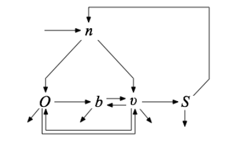

**Figure 1. Diagram of different user behaviors in a Twitch session.** Arrows ending on other arrows represent unidirectional transitions between two user groups. where O represents the number of people currently on an offline channel; b represents the number of people browsing directories on Twitch; $upsilon$ represents the number of people actively viewing a video; S represents the number of people that have 'succeded' by watching a video for 5 continuous minutes1; n represents the number of users that are ready to initiate a session.

```python
figure_1 = '''<center><figure id="Figure 1">
<img src="data:…" width="300px">
<caption><font color="gray">
<b>Figure 1. Diagram of different user behaviors in a Twitch session.</b>
Arrows ending on other arrows represent unidirectional transitions between two user groups.
where O represents the number of people currently on an offline channel;
b represents the number of people browsing directories on Twitch;
$upsilon$ represents the number of people actively viewing a video;
S represents the number of people that have 'succeded' by watching a video for 5 continuous minutes1;
n represents the number of users that are ready to initiate a session.
</font></caption>
</figure></center>'''

fig = plt.figure(facecolor='none', figsize=[5,3])
ax= fig.add_axes([0, 0, 1, 1])
ax.imshow(plt.imread('Model Diagram.png'))
ax=plt.gca()
ax.set_xticks([])
ax.set_yticks([])
plt.box(False)
plt.close()
HTML(figure_1.replace('$figure_data', figure_data_stream(fig)))
```

The conceptual model, shown in Figure 1, divides users into different groups according to their current activities. As users interact with the Twitch platform, their activity changes and thus they transition from one state to another, as shown by the arrows in Figure 1.

A detailed description of this model, by using an individual user as an example, is as follows.

We begin with a user that becomes available to initiate a Twitch session. In our model, this user is in state *n* and transitioned to *n* externally from the system through "→ *n*". Once available to initiate a session, there are 2 possibilities: they can (1) start the session on a channel that is offline, thus they transition to the *O* state through the "$n$ → $O$" arrow; or (2) start a session on a channel that is currently live, thus they transition to the $\upsilon$ state through "*n* → $\upsilon$" arrow. An assumption of the model is that the user cannot start the session browsing videos. Users on offline channels, represented by $O$, can either fail and navigate away from the Twitch website, shown by the diagonal arrow pointing outwards from the system; begin browsing available channels, shown by the "$O$ → $b$" arrow; or go directly to a live channel, shown by the "$O$ → $\upsilon$" arrow. Similarly, users on live channels, represented by $\upsilon$, can fail; go back to browsing videos, shown by the "$\upsilon$ → $b$" arrow; follow a direct link to an offline channel, shown by the "$\upsilon$ → $O$" arrow; or succesfully complete a session, shown by the "$\upsilon$ → $S$" arrow. Users that are browsing videos are assumed to either fail or browse to a live channel, shown by the "$b$ → $\upsilon$" arrow. Once a user has had a succesful session, represented by $S$, they can either become available to initiate a become new session "$S$ → $n$" arrow, or fail. Recall that this model assumes that the group that fails at the highest rate are users on offline channels.

A mathematical model for this conceptual model is proposed for rigorous analysis. However, models of different types can be used to obtain different types of understanding. For example, one could model the behavior of a individual user using a probabilistic model and a Monte Carlo approach. Repeating the experiment may provide information regarding different trends such as population averages. Another alternative is to use deterministic models, such as those defined by systems of differential equations, that purposefully model the average behavior of the users. The advantage of the deterministic model, as shown in this analysis, is that we can find conditions among the parameters, variables and rates of the system to identify principles through numerical and analytical methods.

Here, I analyze a deterministic model of User Sessions at the Population Level, thus I am looking at population averages and not individual users. The mathematical model I analyze is reproduced below from the Methods section,

```python
ds.equations
```

\begin{equation}\dot{O } = \alpha_1 \omega ^{-1}n + \omega ^{-0.5}k_{31} \upsilon -k_{12} O -\omega ^{0.5}k_{13} O -\beta_1 O \\\dot{b } = k_{12} O + k_{32} \upsilon -k_{23} b -\beta_2 b \\\dot{\upsilon } = k_{23} b + \omega \alpha_2 n + \omega ^{0.5}k_{13} O -0.2\sigma \upsilon -\beta_3 \upsilon -k_{32} \upsilon -\omega ^{-0.5}k_{31} \upsilon \\\dot{S } = 0.2\sigma \upsilon -k_{45} S -\beta_4 S \\\dot{n } = \alpha_5 + k_{45} S -\alpha_1 \omega ^{-1}n -\omega \alpha_2 n \\\end{equation}

where the $\omega$ parameter represents a the bias for initiating sessions on live vs offline channels. For a complete description of the parameters, please refer to the Methods section.

#### Analysis of System Behaviors from a Global Perspective

```python
html_string = '''
Using the system design space approach the complete set of qualitatively distinct behaviors
can be determined, without specifying values for the parameters. For this system,
the number of possible dominant modes that the model can exhibit can be
enumerated, which yields a total of <b>''' + str(len(valid_cases)) + '''</b>
dominant modes.
Each of these behaviors can be analyzed and the results reasembled to gain a better idea of
more global properties of system behavior.
'''

HTML(html_string)
```

Using the system design space approach the complete set of qualitatively distinct behaviors can be determined, without specifying values for the parameters. For this system, the number of possible dominant modes that the model can exhibit can be enumerated, which yields a total of **695** dominant modes. Each of these behaviors can be analyzed and the results reasembled to gain a better idea of more global properties of system behavior.

Here, I show the analysis of the each of the dominant modes of the system, also called *Cases* in the parlance of the design space method. I will show the sensitivity of succesful users as a function of the rate constant for transition from offline channel to browsing, "$O$ → $b$", represented by $k_{12}$; and the live bias, represented by $\omega$. The parameter sensitivities are calculated as $\partial \log S_0/\partial \log k_{12}$ and $\partial \log S_0/\partial \log \omega$, respectively, where $S_0$ represents the steady state solution of $S$. The design space method calculates the steady-state solution for each Case of the system analytically.

The results of the analysis will be displayed in a table constructed programmatically using python. In the next block I define an html template that will have the main body replaced later on.

```python
# Create the html template for each cell with a style wildcard
row_template = ['<td style="$style_'+str(i)+';{'+str(i+3)+'}">{'+str(i)+'}</td>'
                for i in range(3)]
# Define a list of style definitions where the first 2 are shared for all cells,
# the 3rd is only used for the 4th column of each row.
style = ['border:0',
         'text-align:center',
         'border-left:1px solid black'
         ]

colors = ['background-color:#e4685d', 'background-color:yellow', 'background-color:#5cbf2a', 'background-color:light-gray']
# Define the header and footer for the html table, with a wild card for the table body
html_preamble = '''
<div id="$table_number" style="overflow:hidden;max-height:200px">
<center>
<table style="border:1px solid black;text-align:center;" onclick="toggleTableDisplay(this, '$table_number')">
<tr style="border:0;border-bottom:1px solid black;text-align:center;">
<th style="border:0;text-align:center;">Case Number</th>
<th style="border:0;text-align:center;"> &#8706;log S/ &#8706; log <i>k</i><sub>12</sub></th>
<th style="border:0;text-align:center;"> &#8706; log S/&#8706; log &omega;</th>
<th style="border:0;border-left:1px solid black;text-align:center;">Case Number</th>
<th style="border:0;text-align:center;"> &#8706;log S/ &#8706; log <i>k</i><sub>12</sub></th>
<th style="border:0;text-align:center;"> &#8706; log S/&#8706; log &omega;</th>
<th style="border:0;border-left:1px solid black;text-align:center;">Case Number</th>
<th style="border:0;text-align:center;"> &#8706;log S/ &#8706; log <i>k</i><sub>12</sub></th>
<th style="border:0;text-align:center;"> &#8706; log S/&#8706; log &omega;</th>
</tr>
$table_body
<caption><b>$table_number. $title</b> $caption [Click table to expand]</caption>
</table></center></div>
'''

def create_table_subcases(cases, table_number=0, title='', caption=''):
    table_body = ''
    for index,case in enumerate(cases):
        styles = [';'.join(style[:2+(index % 3 if i == 0 else 0)]) for i in xrange(3)]
        data = ['<b>'+case.case_number+'</b>',
                case.ssystem.log_gain('S', 'k12'),
                case.ssystem.log_gain('S', 'om')]
        color_style = [colors[i]
                       for datum in data[1:]
                       for i,test in enumerate([datum < 0, datum == 0, datum > 0])
                       if test is True]
        data = data + [colors[3]] + color_style
        row = ''.join([row_template[i].replace('$style_'+str(i), styles[i]) for i in xrange(3)])
        row = row.format(*data)
        if index % 3 == 0:
            row = '<tr style="border:0;text-align:center;">'+row
        elif index % 3 == 2:
            row = row+'</tr>'
        table_body += row
    table = html_preamble.replace('$table_body', table_body)
    table = table.replace('$table_number', 'Table '+str(table_number))
    table = table.replace('$title', title)
    table = table.replace('$caption', caption)
    return table
```

Analysis of the full set of dominant modes, shown in Table 1, reveals some interesting behaviors that may appear to be counter-intuitive.

```python
title_str = 'Enumeration of model behaviors showing response to local variations in system parameters.'
caption_str = 'Cells are colored according to coupling: green \
for directly coupled; red for inversely coupled; yellow for uncoupled.'
HTML(create_table_subcases(cases,
                           table_number=1,
                           title=title_str,
                           caption=caption_str))
```

| Case Number | ∂log S/ ∂ log *k*<sub>12</sub> | ∂ log S/∂ log ω | Case Number | ∂log S/ ∂ log *k*<sub>12</sub> | ∂ log S/∂ log ω | Case Number | ∂log S/ ∂ log *k*<sub>12</sub> | ∂ log S/∂ log ω |
| --- | --- | --- | --- | --- | --- | --- | --- | --- |
| **3_1** | 1.0 | -0.0 | **3_2** | -0.0 | -0.0 | **3_3** | -0.0 | -0.0 |
| **3_4** | -0.0 | -0.0 | **5** | -0.0 | -0.0 | **9** | -0.0 | -0.0 |
| **13** | -0.0 | -0.0 | **36_5_1** | 1.0 | 2.0 | **36_5_2** | -0.0 | 2.0 |
| **36_5_3** | -0.0 | -0.0 | **36_5_4** | -0.0 | -0.0 | **36_11** | -0.0 | -0.0 |
| **36_14** | -0.0 | -0.0 | **38** | -0.0 | -0.0 | **42** | -0.0 | -0.0 |
| **46** | -0.0 | -0.0 | **97** | -0.0 | -0.0 | **101** | -0.0 | -0.0 |
| **105** | -0.0 | -0.0 | **109** | -0.0 | -0.0 | **113** | -0.0 | -0.0 |
| **117** | -0.0 | -0.0 | **121** | -0.0 | 0.5 | **125** | -0.0 | 0.5 |
| **129** | -0.0 | 2.0 | **132_26** | -0.0 | -0.0 | **132_29** | -0.0 | -0.0 |
| **132_30** | -0.0 | 2.0 | **133** | -0.0 | 2.0 | **134** | -0.0 | -0.0 |
| **137** | -0.0 | 2.0 | **138** | -0.0 | -0.0 | **141** | -0.0 | 2.0 |
| **142** | -0.0 | -0.0 | **145** | -0.0 | 2.0 | **149** | -0.0 | 2.0 |
| **153** | -0.0 | 2.5 | **157** | -0.0 | 2.5 | **161** | -1.0 | 0.5 |
| **165** | -1.0 | 0.5 | **169** | -1.0 | 0.5 | **173** | -1.0 | 0.5 |
| **177** | -1.0 | 0.5 | **181** | -1.0 | 0.5 | **185** | -1.0 | 1.0 |
| **189** | -1.0 | 1.0 | **209_1** | -0.0 | -0.0 | **209_17** | -0.0 | -0.0 |
| **210_34** | -0.0 | -0.0 | **210_50** | -0.0 | -0.0 | **211_11_1** | 1.0 | -0.0 |
| **211_11_2** | -0.0 | -0.0 | **211_11_3** | -0.0 | -0.0 | **211_11_4** | -0.0 | -0.0 |
| **212_44_5_1** | 1.0 | 2.0 | **212_44_5_2** | -0.0 | -0.0 | **212_44_5_3** | -0.0 | -0.0 |
| **212_44_5_4** | -0.0 | -0.0 | **212_44_11** | -0.0 | -0.0 | **212_44_12** | -0.0 | -0.0 |
| **212_44_14** | -0.0 | -0.0 | **213_5** | -0.0 | -0.0 | **213_13** | -0.0 | -0.0 |
| **213_21** | -0.0 | -0.0 | **214_38** | -0.0 | -0.0 | **214_46** | -0.0 | -0.0 |
| **214_54** | -0.0 | -0.0 | **228_32_5_1** | 1.0 | 2.0 | **228_32_5_2** | -0.0 | -0.0 |
| **228_32_5_3** | -0.0 | -0.0 | **228_32_5_4** | -0.0 | -0.0 | **228_32_11** | -0.0 | -0.0 |
| **228_32_12** | -0.0 | -0.0 | **228_32_14** | -0.0 | -0.0 | **228_41** | -0.0 | -0.0 |
| **228_44** | -0.0 | -0.0 | **230** | -0.0 | -0.0 | **234** | -0.0 | -0.0 |
| **238** | -0.0 | -0.0 | **324_56** | -0.0 | -0.0 | **324_57** | -0.0 | -0.0 |
| **324_59** | -0.0 | -0.0 | **326** | -0.0 | -0.0 | **330** | -0.0 | -0.0 |
| **334** | -0.0 | -0.0 | **338** | -0.0 | -0.0 | **342** | -0.0 | -0.0 |
| **420_70_1_1** | -0.0 | 2.5 | **420_70_1_2** | -0.0 | -0.0 | **420_70_1_3** | -0.0 | -0.0 |

[output cut: 202 more lines]

Close inspection of Table 1 shows some things we might expect. Increasing the bias for live channels, $\omega$, cannot decrease the number of succesful views (i.e. $\omega$ is either uncoupled from $S$, meaning a change in $\omega$ does not change $S$, or directly coupled, meaning an increase in $\omega$ elicits an increase in $S$). However, increasing the rate at which users transition from offline channels to browsing pages, represented by $k_{12}$, can increase the number of users with succesful views, but and can also decrease the number of succesful views.

This is counter intuitive because of two reasons: (1) the number of users browsing pages should increase proportionally with the decrease in users on offline channels as we increase $k_{12}$; and (2) the rate-constant for failure for users on offline channels is greater than the rate-constant for failure for users that are browsing pages.

The complete set of cases that exhibit an inversely coupling between the rate constant behavior is shown in Table 2.

```python
cases_to_show = [case for case in cases if case.ssystem.log_gain('S', 'k12') < 0.]
title_str = 'Enumeration of model behaviors showing decrease of succesful sessions in response to increase of $O$ &rarr; $b$ transition.'
caption_str = 'Cells are colored according to coupling (see caption for <a href="#Table 1">Table 1</a> for details).'
HTML(create_table_subcases(cases_to_show,
                           table_number=2,
                           title=title_str,
                           caption=caption_str))
```

| Case Number | ∂log S/ ∂ log *k*<sub>12</sub> | ∂ log S/∂ log ω | Case Number | ∂log S/ ∂ log *k*<sub>12</sub> | ∂ log S/∂ log ω | Case Number | ∂log S/ ∂ log *k*<sub>12</sub> | ∂ log S/∂ log ω |
| --- | --- | --- | --- | --- | --- | --- | --- | --- |
| **161** | -1.0 | 0.5 | **165** | -1.0 | 0.5 | **169** | -1.0 | 0.5 |
| **173** | -1.0 | 0.5 | **177** | -1.0 | 0.5 | **181** | -1.0 | 0.5 |
| **185** | -1.0 | 1.0 | **189** | -1.0 | 1.0 | **420_70_1_4** | -1.0 | 2.5 |
| **451_1_4** | -1.0 | 0.5 | **516_85_22** | -1.0 | 2.5 | **547_22** | -1.0 | 0.5 |
| **1572_248_1_4** | -1.0 | 1.0 | **1625_161_25** | -1.0 | 1.0 | **1626_162_58** | -1.0 | 1.0 |
| **1627_67_1_4** | -1.0 | 1.0 | **1627_163_11_3** | -1.0 | 1.0 | **1628_164_44_3** | -1.0 | 1.0 |
| **1628_388_1_4** | -1.0 | 1.0 | **1629_165_29** | -1.0 | 1.0 | **1630_166_62** | -1.0 | 1.0 |
| **1668_263_22** | -1.0 | 1.0 | **1721_9** | -1.0 | 1.0 | **1722_330** | -1.0 | 1.0 |
| **1723_75_22** | -1.0 | 1.0 | **1724_396_22** | -1.0 | 1.0 | **1725_13** | -1.0 | 1.0 |
| **1726_334** | -1.0 | 1.0 |  |  |  |  |  |  |

To explore this, I show the analysis of an example, Case "420_70_1_4". The underscores indicate that the dominant mode is a cycle and has a sub-dominant mode – the details of which will be revealed through a detailed description of the dominant mode. The dominant mode involves a cycle that is singular because of rapid cycling between different states. The Design Space Toolbox V2 resolves these singularities by collapsing these cycles into a new state. In this case there is a hierarchy of cycles, where resolving one such cycle creates a new cycle and so on. At each level in this hierarchy of cycles, the dominant mode can be characterized, which can be useful to identify the series of events contributing to the behavior of the system.

A detailed description of this dominant mode is as follows. Starting with Case 420, the dominant mode of the system is represented by the following sub-system,

```python
case=ds('420')
case.equations
```

\begin{equation}\dot{O } = n \alpha_1 \omega ^{-1}-O \omega ^{0.5}k_{13} \\\dot{b } = O k_{12} -b k_{23} \\\dot{\upsilon } = n \omega \alpha_2 -0.2\upsilon \sigma \\\dot{S } = 0.2\upsilon \sigma -S k_{45} \\\dot{n } = S k_{45} -n \omega \alpha_2 \\\end{equation}

which reveals the following characteristics. New sessions start predominantly on live channels because the dominant process contributing to the loss of *n* is given $\alpha_2\omega n$, thus $\alpha_2\omega n > \alpha_1\omega^{-1} n$. Then, the majority of users on live channels proceed to have succesful sessions given by the dominant process contributing to loss of $\upsilon$. The majority of users that have succesful session proceed to initiate a new session - thus there is a dominant cycle between *n* → $\upsilon$ → *S* → *n*.

Among the users that start the session on an offline channel, the majority proceed to navigate directly to a live channel through a direct link or via their personal "following directory", thus by-passing browsing channels. Among the users that end up browsing pages on Twitch, the majority originate from offline channels and end up watching a live channel.

Analysis of the dominant mode given by the equations in Out [14]: has no solution because the cycle between *n* → $\upsilon$ → *S* → *n* is underdetermined and has a solution subspace that is resolved by considering minor processes contributing to the new users enetering the cycle and users exiting the cycle.

Sub-case 70 of Case 420 is defined by collapsing the cycle and considering sub-dominant processes, as shown by the following system of differential equations,

```python
sub1 = case('70')
sub1.equations
```

\begin{equation}\dot{O } = 0.2\upsilon \alpha_1 \omega ^{-2}\alpha_2 ^{-1}\sigma -O \omega ^{0.5}k_{13} \\\dot{b } = O k_{12} -b k_{23} \\\dot{\upsilon } = O \omega ^{0.5}k_{13} -0.2\upsilon \alpha_1 \omega ^{-2}\alpha_2 ^{-1}\sigma \\S = 0.2\upsilon \sigma k_{45} ^{-1}\\n = 0.2\upsilon \omega ^{-1}\alpha_2 ^{-1}\sigma \\\end{equation}

Where $S$ and $n$ are no longer represented as time-dependent variables because they reach a rapid equilibrium relative to the remaining variables of the system. In this dominant mode, users in the cycle $n \rightarrow \upsilon \rightarrow S \rightarrow n \rightarrow \dots$ originate directly from users on offline channels and the majority that leave the cycle start a new session an offline channel. Therefore, there is second cycle between $O$ and the combined pool of $(\upsilon+S+n)$. Again, the solution of the approximation can be resolved by considering input and output into this new cycle.

Sub-case 1 of Case 420_70 is defined by the following system of differential equations,

```python
sub2 = sub1('1')
sub2.equations
```

\begin{equation}\dot{O } = b k_{23} -O k_{12} \\\dot{b } = O k_{12} -b k_{23} \\\upsilon = 5O \alpha_1 ^{-1}\omega ^{2.5}k_{13} \alpha_2 \sigma ^{-1}\\S = 0.2\upsilon \sigma k_{45} ^{-1}\\n = 0.2\upsilon \omega ^{-1}\alpha_2 ^{-1}\sigma \\\end{equation}

where the system now has two differential equations, one for the collapsed pool involving $(0+V+S+n)$ and one for users browsing pages. In this sub-case, most of the remaining users on offline channels originate from users browsing channels via $b \rightarrow \upsilon \rightarrow S \rightarrow n \rightarrow O$ and they end up browsing pages. Thus, there is another cycle between $b$ and $(O+\upsilon + S + n)$ that can be resolved.

Sub-case 4 of Case 420_70_1 is defined by the following system of differential equations,

```python
sub3 = sub2('4')
sub3.equations
```

\begin{equation}\dot{O } = \alpha_5 -O k_{12} k_{23} ^{-1}\beta_2 \\b = O k_{12} k_{23} ^{-1}\\\upsilon = 5O \alpha_1 ^{-1}\omega ^{2.5}k_{13} \alpha_2 \sigma ^{-1}\\S = 0.2\upsilon \sigma k_{45} ^{-1}\\n = 0.2\upsilon \omega ^{-1}\alpha_2 ^{-1}\sigma \\\end{equation}

which essentially says that the system is in a rapid equilibrium relative to the rate of new users initiating sessions and those failing to watch a video succesfully. Note that, from the hierarchy of cycle, we know that the variable with the slowest turnover-rate is $b$ and this behavior is independent of *specific values* for the parameters and is true as long as a series of constraints are valid. A subset of the inequalities that must be valid is shown below,

```python
dspace.Equations([str(i) for i in sub3.boundaries[:5]], latex_symbols=symbols)
```

\begin{equation}k_{12} \beta_1 ^{-1}k_{23} ^{-1}\beta_2 > 1\\0.2000000019968105\alpha_1 \omega ^{-2.5}k_{12} k_{13} ^{-1}k_{23} ^{-1}\beta_2 \alpha_2 ^{-1}\sigma \beta_3 ^{-1} > 1\\\alpha_1 \omega ^{-2.5}k_{12} k_{13} ^{-1}k_{23} ^{-1}\beta_2 \alpha_2 ^{-1}k_{45} \beta_4 ^{-1} > 1\\k_{23} \beta_2 ^{-1} > 1\\k_{12} \beta_1 ^{-1} > 1\\\end{equation}

where the left-hand side of the equations are products of power-laws and the right-hand side is equal to 1. These equations are known as posynomials in the field of geometric programming. When transformed into logarithmic space, these inequalities become linear

```python
dspace.Equations([str(i) for i in sub3.boundaries_log[:5]], latex_symbols=symbols)
```

\begin{equation}\log(k_{12} )-\log(\beta_1 )-\log(k_{23} ) + \log(\beta_2 ) > 0\\-0.6989700000000000 + \log(\alpha_1 )-2.5\log(\omega ) + \log(k_{12} )-\log(k_{13} )-\log(k_{23} ) + \log(\beta_2 )-\log(\alpha_2 ) + \log(\sigma )-\log(\beta_3 ) > 0\\\log(\alpha_1 )-2.5\log(\omega ) + \log(k_{12} )-\log(k_{13} )-\log(k_{23} ) + \log(\beta_2 )-\log(\alpha_2 ) + \log(k_{45} )-\log(\beta_4 ) > 0\\\log(k_{23} )-\log(\beta_2 ) > 0\\\log(k_{12} )-\log(\beta_1 ) > 0\\\end{equation}

and define a convex polytope within which this dominant mode is a valid approximation of the full system.

A diagramatic representation of the relative rates for the transitions between states for this dominant mode is shown in Figure 2.

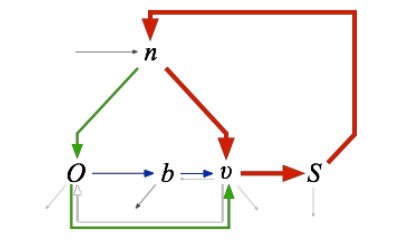

**Figure 2. Diagram showing the most important transitions between different user groups.** The weight and color of the arrows corresponds to the ranking of different transitions steps. Largest rates (red); second largest rates (green); third largest rates (blue); fourth largest rates (dark gray); and smallest rates (light gray).

```python
figure_2 = '''<center><figure>
<img src="data:…" width="300px">
<caption><font color="gray"><b>Figure 2. Diagram showing the most
important transitions between different user groups. </b>
The weight and color of the arrows corresponds to the ranking of
different transitions steps.  Largest rates (red);
second largest rates (green); third largest rates (blue);
fourth largest rates (dark gray); and smallest rates (light gray).
</font></caption>
</figure></center>'''

fig = plt.figure(facecolor='none', figsize=[5,3])
ax= fig.add_axes([0, 0, 1, 1])
ax.imshow(plt.imread('primary_path.png'))
ax=plt.gca()
ax.set_xticks([])
ax.set_yticks([])
plt.box(False)
plt.close()
HTML(figure_2.replace('$figure_data', figure_data_stream(fig)))
```

The answer to the question as to why this particular model behavior exhibits the counter-intuitive decrease in succesful sessions can now be properly described. As discussed previously, the system is essentially in rapid equilibrium and the slowest internal transition within system is $O \rightarrow b \rightarrow \upsilon$. If we increase the transition rate-constant from $O \rightarrow b$, it pulls users away from $O$ and because $O$ is in rapid equilibrium with the combined $\upsilon$+*S*+*n* pool, it also pulls users away from this cycle and thus decreases the number of users performing each of these activities.

This can be seen from the steady-state solutions, which the Design Space Toolbox automatically calculates. As we can see, the steady-state solution for all the variables except $b$ are inversely proportional to $k_{12}$.

```python
sub3.ssystem.solution
```

\begin{equation}O = k_{12} ^{-1}k_{23} \beta_2 ^{-1}\alpha_5 \\b = \beta_2 ^{-1}\alpha_5 \\\upsilon = 4.9999999500797383\alpha_1 ^{-1}\omega ^{2.5}k_{12} ^{-1}k_{13} k_{23} \beta_2 ^{-1}\alpha_2 \sigma ^{-1}\alpha_5 \\S = \alpha_1 ^{-1}\omega ^{2.5}k_{12} ^{-1}k_{13} k_{23} \beta_2 ^{-1}\alpha_2 k_{45} ^{-1}\alpha_5 \\n = \alpha_1 ^{-1}\omega ^{1.5}k_{12} ^{-1}k_{13} k_{23} \beta_2 ^{-1}\alpha_5 \\\end{equation}

To show that this is indeed the situation, we can simulate the full system using a representative set of parameter values. Using the Design Space Method, I can automatically determine a set of values for the parameters such that the behavior is consistent with Case 420_70_1_4. In addition, I can impose constraints among the variables and parameters of the system such that they must be satisfied - otherwise the program indicates that the constraints are simply not feasible. For example, we might expect the number of new users initiating sessions per minute to be more than 100. In addition, the expectation may be that the number of users on live channels that have not succeeded to be in the millions of users. We impose constraints in the model behavior and determine if this behavor is at all possible, somewhere in parameter space

```python
sub3 = ds('420_70_1_4', constraints=['a5 > 100', 'v < 10000000',
                                     'v > 1000000','v > 10*S', 'v < 100*S'])
is_valid = sub3.is_valid()

HTML('Dominant modes given by Case number 420_70_1_4 is valid? <b>'+str(is_valid)+'</b>')
```

Dominant modes given by Case number 420_70_1_4 is valid? **True**

and then automatically determine a set of values for the parameters such that this behavior is observed that satisfies the constraints we have imposed,

```python
pvals = sub3.valid_interior_parameter_set()


for i in pvals:
    pvals[i] = pvals[i] + pvals[i]*random.gauss(0, 0.00001)

html_str = ',<br>'.join(['${0}$ = {1}'.format(ds._latex[i], pvals[i]) for i in pvals])
HTML(html_str)
```

$k_{13}$ = 74.9903652565,  
$k_{12}$ = 31.6227451345,  
$\omega$ = 1.77826987687,  
$k_{31}$ = 0.00843386804575,  
$k_{32}$ = 0.00200003546261,  
$k_{45}$ = 2.00000037874,  
$k_{23}$ = 3.16225881804,  
$\alpha_1$ = 1.00002130816,  
$\sigma$ = 0.31622911129,  
$\alpha_2$ = 0.999992565304,  
$\alpha_5$ = 6324.61210991,  
$\beta_1$ = 3.16224652032,  
$\beta_2$ = 0.999987383683,  
$\beta_3$ = 0.000632459877027,  
$\beta_4$ = 0.0200002343615

Using this set of values for the parameters, the full system can be simulated as shown below,

```python
ode_equations = [i.split(' = ')[1] for i in f]
ode_equations = [i.replace('^', '**') for i in ode_equations]
ode_equations = [i.replace('1/5', '0.2') for i in ode_equations]
ode_equations = {ds.dependent_variables[i]: eq for i,eq in enumerate(ode_equations)}
ics = {i:1 for i in ds.dependent_variables}
```

```python
# I perform a series of simulations where I simulate the system
# behavior for sufficient time as to reach steady state, store the
# final values, increase the value for the parameter on the x-axis
# and repeat.  Thus generating the induction curve for the system
# in response to a particular variable.
k12_0 = pvals['k12']
k12 = k12_0*np.logspace(-2, 2, 100)
output_1 = np.zeros(100)
output_2 = np.zeros(100)
output_3 = np.zeros(100)
for i,xi in enumerate(k12):
    pvals['k12'] = xi
    t,x = integrate(ode_equations, ics, pvals, 0, 10000000, 0)
    output_1[i] = x['S'][-1]
    output_2[i] = x['v'][-1]
    output_3[i] = x['O'][-1]
pvals['k12'] = k12_0
```

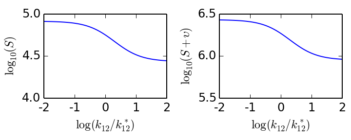

**Figure 3. Numerical simulation of the full system showing changes in steady state as a function of the transition rate-constant from $O \rightarrow b$.** The $x$-axis represents the logarithm of the $k_{12}$ parameter, normalized with respect to the value acquired automatically for case 420_70_1_4, represented by $k_{12}^*$. The $y$-axis represents the logarithm of the the steady-state value for the number of users that have succesfully watched a stream for 5 mins (left) and the total number of users watching videos, $S + \upsilon$(right).

```python
figure_3 = r'''<center><figure id="Figure 3">
<img src="data:…" width="600px">
<caption><font color="gray"><b>Figure 3. Numerical simulation
of the full system showing changes in steady state as a function
of the transition rate-constant from $O \rightarrow b$. </b>
The $x$-axis represents the logarithm of the
$k_{12}$ parameter, normalized with respect to the value
acquired automatically for case 420_70_1_4, represented by $k_{12}^*$.
The $y$-axis represents the logarithm of the the steady-state value
for the number of users that have succesfully watched a stream for
5 mins (left) and the total number of users watching videos, $S + \upsilon$(right).
</font></caption>
</figure></center>'''

fig = plt.figure(figsize=[5, 2], facecolor='none', dpi=144)
ax = fig.add_axes([0.125, 0.3, 0.35, 0.6])
ax.plot(np.log10(k12), np.log10(output_1))
ax.set_xlim(np.log10(k12_0)+np.array([-2., 2.]))
ax.set_xticks(np.log10(k12_0)+np.array([-2., -1., 0., 1., 2.]))
ax.set_xticklabels([ -2, -1, 0, 1, 2])
ax.set_yticks([4., 4.5, 5.])
ax.set_xlabel(r'$\log\left(k_{12}/k_{12}^*\right)$')
ax.set_ylabel(r'$\log_{10}(S)$')

ax = fig.add_axes([0.625, 0.3, 0.35, 0.6])
ax.plot(np.log10(k12), np.log10(output_1+output_2))
ax.set_xlim(np.log10(k12_0)+np.array([-2., 2.]))
ax.set_xticks(np.log10(k12_0)+np.array([-2., -1., 0., 1., 2.]))
ax.set_xticklabels([ -2, -1, 0, 1, 2])

ax.set_yticks([5.5, 6., 6.5])
ax.set_xlabel(r'$\log\left(k_{12}/k_{12}^*\right)$')
ax.set_ylabel(r'$\log_{10}(S+\upsilon)$')
html_string=HTML(figure_3.replace('$figure_data', figure_data_stream(fig)))
plt.close()
html_string
```

confirming that by increasing $k_{12}$ there is indeed a decrease in number of users who have succesfully watched a video and a general decrease in total viewers $(S + \upsilon)$. One should note that there are transitions between dominant modes of the system. At low values for $k_{12}$, $S$ and $\upsilon$ are uncoupled from $k_{12}$; then, as $k_{12}$ increases, both become inversely coupled; finally, if we increase $k_{12}$ further, $S$ and $\upsilon$ again become uncoupled from $k_{12}$. This shows a qualitative change in system behavior, each corresponding to a unique dominant mode of the system. The deconstruction into dominant modes is visualized in a 2-D plot as shown in Figure 4.

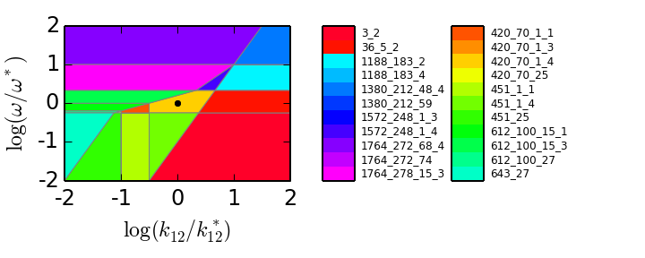

**Figure 4. Visual representation of the design space deconstruction of the full system into model behaviors.** The $x$-axis represents the logarithm of the $k_{12}$ parameter, normalized with respect to the value acquired automatically for case 420_70_1_4, represented by $k_{12}^*$. The $y$-axis represents the logarithm of the $\omega$ parameter, normalized with respect to the value acquired automatically for case 420_70_1_4, represented by $\omega^*$. Dominant modes are shown by regions with different colors, where each color corresponds to a particular case of the system, shown by the colorbar.

```python
figure_4 = r'''<center><figure id="Figure 4">
<img src="data:…" width="700px">
<caption><font color="gray"><b>Figure 4. Visual representation of the
design space deconstruction of the full system into model behaviors.</b>
The $x$-axis represents the logarithm of the
$k_{12}$ parameter, normalized with respect to the value
acquired automatically for case 420_70_1_4, represented by $k_{12}^*$.
The $y$-axis represents the logarithm of the
$\omega$ parameter, normalized with respect to the value
acquired automatically for case 420_70_1_4, represented by $\omega^*$.
Dominant modes are shown by regions with
different colors, where each color corresponds to a particular case
of the system, shown by the colorbar.
</font></caption>
</figure></center>'''

pvals['k12'] = k12_0
om_0 = pvals['om']
fig = plt.figure(figsize=[5, 2], facecolor='none', dpi=144)
ax = fig.add_axes([0.1, 0.3, 0.35, 0.6])
color_map=ds.draw_2D_slice(ax, pvals, 'k12', 'om',
                        [k12_0*1e-2, k12_0*1e2],
                        [om_0*1e-2, om_0*1e2],
                        colorbar=False, ec='gray', lw=0.5)
ax.plot(np.log10(k12_0), np.log10(om_0), 'k.')
ax.set_xlim(np.log10(k12_0)+np.array([-2., 2.]))
ax.set_xticks(np.log10(k12_0)+np.array([-2., -1., 0., 1., 2.]))
ax.set_xticklabels([ -2, -1, 0, 1, 2])
ax.set_ylim(np.log10(om_0)+np.array([-2., 2.]))
ax.set_yticks(np.log10(om_0)+np.array([-2., -1., 0., 1., 2.]))
ax.set_yticklabels([ -2, -1, 0, 1, 2])
ax.set_xlabel(r'$\log\left(k_{12}/k_{12}^*\right)$')
ax.set_ylabel(r'$\log\left(\omega/\omega^*\right)$')

color_keys = sorted(color_map)
colors_1 = color_keys[:len(color_keys)/2]
colors_2 = color_keys[len(color_keys)/2:]

ax = fig.add_axes([0.5, 0.3, 0.05, 0.6])
ds.draw_region_colorbar(ax, {i:color_map[i] for i in colors_1}, fontsize='6')

ax = fig.add_axes([0.7, 0.3, 0.05, 0.6])
ds.draw_region_colorbar(ax, {i:color_map[i] for i in colors_2}, fontsize='6')


html_string=HTML(figure_4.replace('$figure_data', figure_data_stream(fig)))
plt.close()
html_string
```

The characteristic behavior of the system in response to changes in $\omega$ and $k_{12}$ for each region of Figure 4 can be determined by looking at the corresponding entries in Table 1.

### How should we increase the number of succesful viewers?

I analyze the model behavior to identify critical parameters that result in an increase in succesful viewers. To do this, I use the design space toolbox to calculate the parameter sensitivities and log-gain factor for signal amplification for each combination of dependent variable and parameters of the system. The results are shown in Table 3.

```python
# Define the header and footer for the html table, with a wild card for the table body
html_preamble = '''<div id="$table_number" style="overflow:hidden;max-height:200px">
                   <center>
                   <table style="border:1px solid black;text-align:center;" onclick="toggleTableDisplay(this, '$table_number')">
                   <tr style="border:0;border-bottom:1px solid black;text-align:center;">
                   $table_header
                   </tr>
                   $table_body
                   <caption><b>$table_number. $title</b> $caption [Click table to expand]</caption>
                   </table></center></div>'''



def create_table_log_gains(case, table_number=0, title='', caption=''):
    table_body = ''
    header_cell = '<th style="border:0;text-align:center;">{0}</th>'
    row_header_cell = '<td style="border:0;text-align:center;">{0}</td>'
    row_data_cell = '<td style="border:0;text-align:center;{0};">{1}</td>'
    table_header = ''.join([header_cell.format(i)
                            for i in ['Dependent<br>Variables']+['$'+symbols[j]+'$' for j in ds.independent_variables]])
    for xd in ds.dependent_variables:
        row = [row_header_cell.format('$'+(symbols[xd] if xd in symbols else xd)+'$')]
        data = [sub3.ssystem.log_gain(xd, xi) for xi in ds.independent_variables]
        data = [(colors[i],datum) for datum in data for i,test in enumerate([datum < 0, datum == 0, datum > 0]) if test is True]
        row += [row_data_cell.format(color, datum) for color,datum in data]
        row = ''.join(row)
        table_body += '<tr style="border:0;text-align:center;">'+row+'</tr>'
    table = html_preamble.replace('$table_body', table_body)
    table = table.replace('$table_header', table_header)
    table = table.replace('$table_number', 'Table '+str(table_number))
    table = table.replace('$title', title)
    table = table.replace('$caption', caption)
    return table
```

```python
HTML(create_table_log_gains(sub3, table_number=3,
                            title='Parameter sensitivities for Case 420_70_1_4',
                            caption='''Parameter sensitivities defined as the
                            partial derivative of a state variable with respect
                            to a parameter or independent variable. Colors represent
                            different coupling (see caption of <a href="#Table 1">Table 1</a>).'''))
```

**Table 3. Parameter sensitivities for Case 420_70_1_4** Parameter sensitivities defined as the partial derivative of a state variable with respect to a parameter or independent variable. Colors represent different coupling (see caption of Table 1). [Click table to expand]

| Dependent Variables | $\alpha_1$ | $\omega$ | $k_{31}$ | $k_{12}$ | $k_{13}$ | $\beta_1$ | $k_{32}$ | $k_{23}$ | $\beta_2$ | $\alpha_2$ | $\sigma$ | $\beta_3$ | $k_{45}$ | $\beta_4$ | $\alpha_5$ |
| --- | --- | --- | --- | --- | --- | --- | --- | --- | --- | --- | --- | --- | --- | --- | --- |
| $O$ | -0.0 | -0.0 | -0.0 | -1.0 | -0.0 | -0.0 | -0.0 | 1.0 | -1.0 | -0.0 | -0.0 | -0.0 | -0.0 | -0.0 | 1.0 |
| $b$ | -0.0 | -0.0 | -0.0 | -0.0 | -0.0 | -0.0 | -0.0 | -0.0 | -1.0 | -0.0 | -0.0 | -0.0 | -0.0 | -0.0 | 1.0 |
| $\upsilon$ | -1.0 | 2.5 | -0.0 | -1.0 | 1.0 | -0.0 | -0.0 | 1.0 | -1.0 | 1.0 | -1.0 | -0.0 | -0.0 | -0.0 | 1.0 |
| $S$ | -1.0 | 2.5 | -0.0 | -1.0 | 1.0 | -0.0 | -0.0 | 1.0 | -1.0 | 1.0 | -0.0 | -0.0 | -1.0 | -0.0 | 1.0 |
| $n$ | -1.0 | 1.5 | -0.0 | -1.0 | 1.0 | -0.0 | -0.0 | 1.0 | -1.0 | -0.0 | -0.0 | -0.0 | -0.0 | -0.0 | 1.0 |

Thus, to improve the number of viewers and succesful sessions there are multiple strategies that can be used. One could improve the bias for landing on an online channel (e.g. channel hosting, increasing overall broadcaster numbers, etc.), the direct transition from offline channels to online channels (e.g. increasing the average number of channels the typical user follows), the transition from browsing to watching videos (e.g. changes to the user interface) and finally increasing the rate for origination of new sessions (e.g. increasing the user base). The pertinent strategy or strategies to pursue would depend on a cost-benefit analysis for the different strategies.

From Table 3, the most effective solution is to increase the bias for live channels relative to offline channels, given that the parameter sensitivity of $\upsilon$ with respect to $\omega$ is equal to 2.5, which means that that an $x$-fold increase in $\omega$ results in a $x^{2.5}$-fold increase in $\upsilon$. One possible way to increase $\omega$ is to increase the number of live channels relative to offline channels, which may be achieved through the feature to host channels. Alternatively, the live bias in this model is expected to increase during important e-sports events, given that a larger number of people are expected to go directly to that particular channel. Another possibility would be to embed the stream of a related live channel in pages that have offline channel according to some calculated metric.

However, these are the local variations and at some point there will be a shift into a different dominant mode, as shown in Figure 3. One can measure the distance to the boundaries resulting in a qualitative change in system behavior, known as the global tolerance to qualitative changes.

```python
# Define the header and footer for the html table, with a wild card for the table body
html_preamble = '''<div id="$table_number" style="overflow:hidden;max-height:200px">
                   <center>
                   <table style="border:1px solid black;text-align:center;" onclick="toggleTableDisplay(this, '$table_number')">
                   <tr style="border:0;border-bottom:1px solid black;text-align:center;">
                   $table_header
                   </tr>
                   $table_body
                   <caption><b>$table_number. $title</b> $caption [Click table to expand]</caption>
                   </table></center></div>'''



def create_table_tolerance(case,
                           table_number=0,
                           title='', caption=''):
    table_body = ''
    header_cell = '<th style="border:0;text-align:center;">{0}</th>'
    row_data_cell = '<td style="border:0;text-align:center;">{0}</td>'
    table_header = ''.join([header_cell.format(i)
                            for i in ['Parameter', 'Fold-decrease', 'Fold-increase']])
    tolerance = case.measure_tolerance(pvals, log_out=False)
    for xi in ds.independent_variables:
        row = [row_data_cell.format('<b>$'+(symbols[xi] if xi in symbols else xi)+'$</b>')]
        data = (tolerance[xi][0] if tolerance[xi][0] > 1e-15 else '&infin;',
                tolerance[xi][1] if tolerance[xi][1] < 1e15 else '&infin;',)
        row += [row_data_cell.format(datum) for datum in data]
        row = ''.join(row)
        table_body += '<tr style="border:0;text-align:center;">'+row+'</tr>'
    table = html_preamble.replace('$table_body', table_body)
    table = table.replace('$table_header', table_header)
    table = table.replace('$table_number', 'Table '+str(table_number))
    table = table.replace('$title', title)
    table = table.replace('$caption', caption)
    return table
```

```python
HTML(create_table_tolerance(sub3,
                            table_number=4,
                            title='Global tolerance for qualitative changes in system behavior',
                            caption = '''The global tolerance defined as the fold-difference
                            required to observe a qualitative change in system behavior.
                            '''))
```

**Table 4. Global tolerance for qualitative changes in system behavior** The global tolerance defined as the fold-difference required to observe a qualitative change in system behavior. [Click table to expand]

| Parameter | Fold-decrease | Fold-increase |
| --- | --- | --- |
| **$\alpha_1$** | 0.316224486575 | 3.16215286502 |
| **$\omega$** | 0.630961678953 | 1.58489976697 |
| **$k_{31}$** | ∞ | 3.16243069321 |
| **$k_{12}$** | 0.316227072125 | 3.16222335126 |
| **$k_{13}$** | 0.316233197001 | 3.16231045492 |
| **$\beta_1$** | 0.316226890364 | 3.1622845991 |
| **$k_{32}$** | ∞ | 3.16232534811 |
| **$k_{23}$** | 0.316233197001 | 3.1622845991 |
| **$\beta_2$** | 0.316227072125 | 3.16222335126 |
| **$\alpha_2$** | 0.316240246024 | 3.16231045492 |
| **$\sigma$** | 0.316226480634 | 3.16222335126 |
| **$\beta_3$** | ∞ | 3.1623386399 |
| **$k_{45}$** | 0.316229051405 | 3.16229051405 |
| **$\beta_4$** | ∞ | 3.16231045492 |
| **$\alpha_5$** | 0.316233197001 | 3.16233197001 |

```python
# I perform a series of simulations where I simulate the system
# behavior for sufficient time as to reach steady state, store the
# final values, increase the value for the parameter on the x-axis
# and repeat.  Thus generating the induction curve for the system
# in response to a particular variable.
om_0 = pvals['om']
om = om_0*np.logspace(-2, 2, 100)
output_1 = np.zeros(100)
output_2 = np.zeros(100)
output_3 = np.zeros(100)
for i,xi in enumerate(om):
    pvals['om'] = xi
    t,x = integrate(ode_equations, ics, pvals, 0, 10000000, 0)
    output_1[i] = x['S'][-1]
    output_2[i] = x['v'][-1]
    output_3[i] = x['O'][-1]
pvals['om'] = om_0
```

```python
# To show the arrow from the reference location to the predicted
# maximal recommended value, we get the indices of the simulation
# closest to these two points.
tolerance = sub3.measure_tolerance(pvals, log_out=False)
index1 = np.argmin((om-om_0)**2)
index2 = np.argmin((om-(om_0*tolerance['om'][1]))**2)
om_log = np.log10(om)
out1_log = np.log10(output_1)
out2_log = np.log10(output_1+output_2)
```

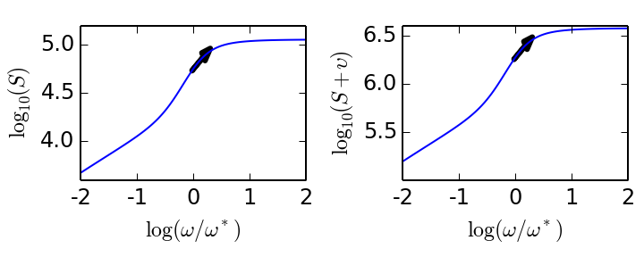

**Figure 5. Numerical simulation of the full system showing changes in steady state as a function of the bias for live channels, $\omega$.** The $x$-axis represents the logarithm of the $\omega$ parameter, normalized with respect to the value acquired automatically for case 420_70_1_4, represented by $\omega^*$. The $y$-axis represents the logarithm of the the steady-state value for the number of users that have succesfully watched a stream for 5 mins (left) and the total number of users watching videos, $S + \upsilon$(right). The predicted increase amount predicted of $\omega$ that is usefule is shown by the black arrows.

```python
figure_5 = r'''<center><figure id="Figure 5">
<img src="data:…" width="600px">
<caption><font color="gray"><b>Figure 5. Numerical simulation
of the full system showing changes in steady state as a function
of the bias for live channels, $\omega$. </b>
The $x$-axis represents the logarithm of the
$\omega$ parameter, normalized with respect to the value
acquired automatically for case 420_70_1_4, represented by $\omega^*$.
The $y$-axis represents the logarithm of the the steady-state value
for the number of users that have succesfully watched a stream for
5 mins (left) and the total number of users watching videos, $S + \upsilon$(right).
The predicted increase amount predicted of $\omega$ that is usefule is
shown by the black arrows.
</font></caption>
</figure></center>'''

fig = plt.figure(figsize=[5, 2], facecolor='none', dpi=144)
ax = fig.add_axes([0.125, 0.3, 0.35, 0.6])
ax.plot(om_log, out1_log)
ax.arrow(om_log[index1],
         out1_log[index1],
         om_log[index2]-om_log[index1],
         out1_log[index2]-out1_log[index1],
         lw=3,
         width=0.005
         )
ax.set_xlim(np.log10(om_0)+np.array([-2., 2.]))
ax.set_xticks(np.log10(om_0)+np.array([-2., -1., 0., 1., 2.]))
ax.set_xticklabels([ -2, -1, 0, 1, 2])
ax.set_yticks([4., 4.5, 5.])
ax.set_xlabel(r'$\log\left(\omega/\omega^*\right)$')
ax.set_ylabel(r'$\log_{10}(S)$')

ax = fig.add_axes([0.625, 0.3, 0.35, 0.6])
ax.plot(np.log10(om), np.log10(output_1+output_2))
ax.arrow(om_log[index1],
         out2_log[index1],
         om_log[index2]-om_log[index1],
         out2_log[index2]-out2_log[index1],
         lw=3,
         width=0.005
         )
ax.set_xlim(np.log10(om_0)+np.array([-2., 2.]))
ax.set_xticks(np.log10(om_0)+np.array([-2., -1., 0., 1., 2.]))
ax.set_xticklabels([ -2, -1, 0, 1, 2])
ax.set_yticks([5.5, 6., 6.5])
ax.set_xlabel(r'$\log\left(\omega/\omega^*\right)$')
ax.set_ylabel(r'$\log_{10}(S+\upsilon)$')
html_string=HTML(figure_5.replace('$figure_data', figure_data_stream(fig)))
plt.close()
html_string
```

Another option that does not involve changing the live bias would be to add additional mechanisms that facilitate direct transitions to live channels without having to browse pages (i.e. increasing $k_{13}$ directly). One such mechanism may be to add an "exploration mode" where users navigate to a popular online channel for a given game (e.g. DOTA 2, LoL) or by genre (e.g. moba, fps, mmo). The channel could be chosen at random from a pool of popular channels.

### Conclusions

The model I have presented involves a series of assumptions that are likely not consistent with the actual system. For example, it does not include users that start a session browsing pages. Furthermore, the parameters of the model are aggregates of multiple parameters that affect the system. For example, the parameter for the bias live vs offline channels cannot be directly related to anything concrete. Nonetheless, this example highlights that even a simple model such as this one can exhibit behaviors that may not be expected through intuitive analysis of the conceptual model, thus highlighting the importance of rigorous mathematical analysis.

The analysis I have presented might not be directly applicable, but it shows my appreciation for the intricacies involved in analyzing complex systems. I reiterate that the goal of this exercise is to show my expertise in mathematical modeling and computer programming with an example showing interesting behaviors. The analysis of dominant modes may not be directly applicable to current models used by the Twitch Data Science team, but illustrates a potential avenue for new analyses. Furthermore, I would like to stress that this is not my sole expertise and that I do have experience working with large data sets and have used methods based on information theory and statistics to identify patterns of co-regulated behaviors, with the goal of predicting causality in gene expression data. I consider my primary competency to be in applying my computer programming skills and my knowledge in mathematics to tackle diverse problems.